# EDA: What makes a Hugging Face model popular?

Author

William Westover

Published

November 4, 2026

This is my exploration of `data/processed/models_clean.csv`, the 3,000 most downloaded models on the Hugging Face Hub (collected November 4, 2026) joined with the arXiv papers they link to.

```python
import pandas as pd
import matplotlib.pyplot as plt

BLUE, ORANGE, GRAY = "#2a78d6", "#eb6834", "#52514e"
plt.rcParams.update({"axes.spines.top": False, "axes.spines.right": False, "axes.grid": True,
                     "grid.alpha": 0.3, "axes.titlelocation": "left"})

models = pd.read_csv("data/processed/models_clean.csv", parse_dates=["created_at", "last_modified", "first_paper_date"])
print(models.shape)
models.head()
```

```
(3000, 28)
```

|  | model_id | author | task | library | license | gated | downloads_30d | downloads_all_time | likes | likes_per_million_downloads | ... | days_since_update | primary_language | num_languages | base_model | num_datasets | num_tags | num_arxiv_papers | first_paper_date | paper_category | days_paper_to_model |
| --- | --- | --- | --- | --- | --- | --- | --- | --- | --- | --- | --- | --- | --- | --- | --- | --- | --- | --- | --- | --- | --- |
| 0 | sentence-transformers/all-MiniLM-L6-v2 | sentence-transformers | sentence-similarity | sentence-transformers | apache-2.0 | False | 181007867 | 4212835278 | 6068 | 1.440360 | ... | 155 | en | 1.0 | nreimers/MiniLM-L6-H384-uncased | 21 | 47 | 5 | 2017-04-18 02:42:17+00:00 | cs.CL | NaN |
| 1 | cross-encoder/ms-marco-MiniLM-L6-v2 | cross-encoder | text-ranking | sentence-transformers | apache-2.0 | False | 65615278 | 682942501 | 439 | 0.642807 | ... | 86 | en | 1.0 | cross-encoder/ms-marco-MiniLM-L12-v2 | 1 | 19 | 0 | NaT | NaN | NaN |
| 2 | BAAI/bge-small-en-v1.5 | BAAI | feature-extraction | sentence-transformers | mit | False | 48832479 | 548501422 | 664 | 1.210571 | ... | 985 | en | 1.0 | NaN | 0 | 22 | 5 | 2023-09-14 10:57:50+00:00 | cs.CL | -3.0 |
| 3 | argmaxinc/whisperkit-coreml | argmaxinc | automatic-speech-recognition | whisperkit | mit | False | 34624804 | 115792061 | 260 | 2.245404 | ... | 76 | NaN | NaN | NaN | 0 | 8 | 0 | NaT | NaN | NaN |
| 4 | Comfy-Org/MiniMax-H3 | Comfy-Org | NaN | diffusion-single-file | other | False | 31913383 | 81719010 | 2518 | 30.812904 | ... | 1 | NaN | NaN | MiniMaxAI/MiniMax-H3 | 0 | 6 | 0 | NaT | NaN | NaN |

5 rows × 28 columns

# Overview

```python
print("Missing values per column:")
print(models.isna().sum()[models.isna().sum() > 0])
```

```
Missing values per column:
task                    391
library                 367
license                 304
num_parameters         1168
params_billions        1168
size_class             1178
created_at              329
created_year            329
age_days                329
primary_language       1435
num_languages          1435
base_model             1763
first_paper_date       1490
paper_category         1490
days_paper_to_model    1666
dtype: int64
```

```python
models[["downloads_30d", "downloads_all_time", "likes", "params_billions", "age_days", "num_arxiv_papers"]].describe().round(1)
```

|  | downloads_30d | downloads_all_time | likes | params_billions | age_days | num_arxiv_papers |
| --- | --- | --- | --- | --- | --- | --- |
| count | 3000.0 | 3.000000e+03 | 3000.0 | 1832.0 | 2671.0 | 3000.0 |
| mean | 800395.5 | 2.139251e+07 | 341.2 | 25.8 | 541.8 | 1.0 |
| std | 4159303.9 | 1.309424e+08 | 966.7 | 129.1 | 427.5 | 2.5 |
| min | 73464.0 | 7.365900e+04 | 0.0 | 0.0 | 2.0 | 0.0 |
| 25% | 102663.8 | 9.632122e+05 | 8.0 | 0.1 | 193.0 | 0.0 |
| 50% | 197897.0 | 2.194754e+06 | 58.0 | 0.5 | 475.0 | 1.0 |
| 75% | 501122.0 | 8.409153e+06 | 241.5 | 7.6 | 779.0 | 1.0 |
| max | 181007867.0 | 4.212835e+09 | 19153.0 | 2779.9 | 1705.0 | 35.0 |

Downloads and likes are really skewed. The median model has about 2.2 million all-time downloads and 58 likes, but the top model (`sentence-transformers/all-MiniLM-L6-v2`) has 4.2 billion downloads on its own. So everything below uses medians and log scales.

# Who uploads the top models?

```python
print("Distinct authors:", models["author"].nunique())
models["author"].value_counts().head(10)
```

```
Distinct authors: 789
```

```
author
OpenMed               315
Qwen                  180
unsloth               128
timm                   82
google                 77
facebook               72
lmstudio-community     68
nvidia                 61
microsoft              56
Comfy-Org              49
Name: count, dtype: int64
```

OpenMed alone has 315 models in the top 3,000, and 237 of them were created on the same day (2025-07-16). That was a bulk upload of medical token-classification models.

```python
print(models[models["author"] == "OpenMed"]["task"].value_counts().head(3))
print(models["created_at"].dt.date.value_counts().head(3))
```

```
task
token-classification    315
Name: count, dtype: int64
created_at
2025-07-16    237
2025-07-18     69
2026-08-18     23
Name: count, dtype: int64
```

# Task

```python
by_task = models.groupby("task").agg(n=("model_id", "size"), median_downloads=("downloads_all_time", "median"), median_likes=("likes", "median"))
by_task["median_downloads"] = by_task["median_downloads"] / 1e6
by_task = by_task[by_task["n"] >= 30].sort_values("n", ascending=False)
by_task.round(1)
```

| task | n | median_downloads | median_likes |
| --- | --- | --- | --- |
| text-generation | 577 | 2.3 | 118.0 |
| image-text-to-text | 382 | 2.1 | 138.0 |
| token-classification | 354 | 1.2 | 0.0 |
| automatic-speech-recognition | 181 | 3.7 | 17.0 |
| sentence-similarity | 120 | 8.5 | 54.0 |
| feature-extraction | 108 | 6.5 | 62.5 |
| text-to-image | 105 | 1.7 | 211.0 |
| image-classification | 89 | 2.7 | 3.0 |
| text-classification | 86 | 3.8 | 71.5 |
| fill-mask | 68 | 18.6 | 74.0 |
| text-to-speech | 59 | 1.0 | 142.0 |
| any-to-any | 47 | 2.1 | 102.0 |
| zero-shot-image-classification | 43 | 6.8 | 58.0 |
| image-to-image | 36 | 1.3 | 405.0 |
| image-feature-extraction | 30 | 5.0 | 18.0 |

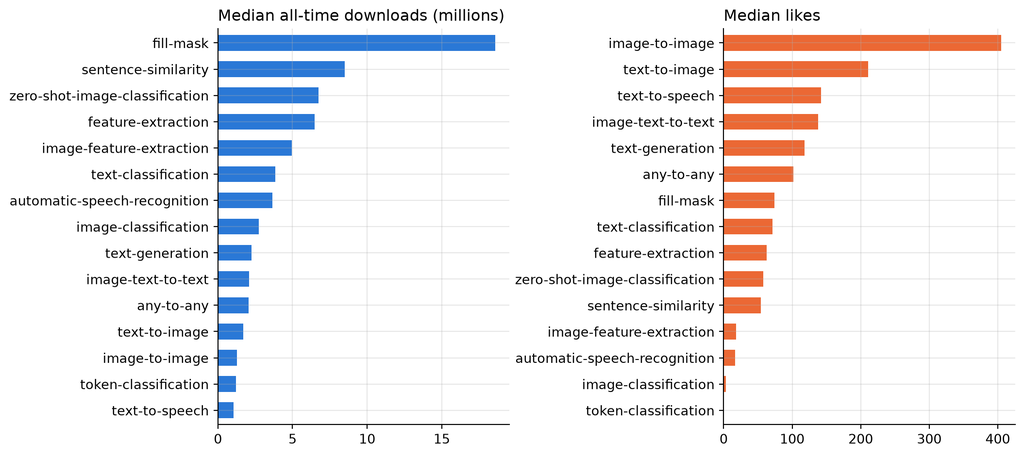

Median all-time downloads and likes by task, for tasks with at least 30 models.

```python
fig, axes = plt.subplots(1, 2, figsize=(11, 5))
by_task.sort_values("median_downloads").plot.barh(y="median_downloads", ax=axes[0], color=BLUE, legend=False, width=0.6)
axes[0].set_title("Median all-time downloads (millions)")
axes[0].set_ylabel("")
by_task.sort_values("median_likes").plot.barh(y="median_likes", ax=axes[1], color=ORANGE, legend=False, width=0.6)
axes[1].set_title("Median likes")
axes[1].set_ylabel("")
plt.tight_layout()
plt.show()
```

# Library and license

```python
by_lib = models.groupby("library").agg(n=("model_id", "size"), median_downloads=("downloads_all_time", "median"), median_likes=("likes", "median"))
by_lib[by_lib["n"] >= 20].sort_values("n", ascending=False).round(0)
```

| library | n | median_downloads | median_likes |
| --- | --- | --- | --- |
| transformers | 1650 | 3112011.0 | 53.0 |
| sentence-transformers | 167 | 8207643.0 | 72.0 |
| diffusers | 137 | 1714119.0 | 265.0 |
| gguf | 125 | 794316.0 | 152.0 |
| diffusion-single-file | 78 | 1660639.0 | 158.0 |
| timm | 77 | 2971949.0 | 2.0 |
| mlx | 31 | 1174542.0 | 37.0 |
| transformers.js | 29 | 924606.0 | 21.0 |
| llama.cpp | 25 | 738966.0 | 88.0 |
| open_clip | 25 | 2450982.0 | 40.0 |

```python
lic = models["license"].value_counts()
print("Share apache-2.0:", round(lic["apache-2.0"] / len(models), 3))
print("Share mit:", round(lic["mit"] / len(models), 3))
lic.head(10)
```

```
Share apache-2.0: 0.554
Share mit: 0.137
```

```
license
apache-2.0               1661
mit                       412
other                     326
cc-by-nc-4.0               63
gemma                      40
cc-by-4.0                  36
cc-by-nc-sa-4.0            20
openrail++                 16
llama3.1                   14
creativeml-openrail-m      14
Name: count, dtype: int64
```

```python
by_lic = models.groupby("license").agg(n=("model_id", "size"), median_downloads=("downloads_all_time", "median"), median_likes=("likes", "median"))
by_lic[by_lic["n"] >= 20].sort_values("median_likes", ascending=False).round(0)
```

| license | n | median_downloads | median_likes |
| --- | --- | --- | --- |
| other | 326 | 1390164.0 | 154.0 |
| gemma | 40 | 2119912.0 | 141.0 |
| mit | 412 | 5312956.0 | 98.0 |
| cc-by-nc-4.0 | 63 | 2474457.0 | 59.0 |
| cc-by-4.0 | 36 | 5671989.0 | 56.0 |
| apache-2.0 | 1661 | 1832142.0 | 46.0 |
| cc-by-nc-sa-4.0 | 20 | 6704869.0 | 23.0 |

Most models use a permissive license (55% apache-2.0 and 14% MIT). The model-specific licenses like gemma and llama have a lot more likes per model, but those are all big-lab releases, so I think it’s the lab and not the license.

# Size

```python
print("Models with a parameter count:", models["num_parameters"].notna().sum())
models.groupby("size_class", observed=True).agg(n=("model_id", "size"), median_downloads=("downloads_all_time", "median"), median_likes=("likes", "median")).round(0)
```

```
Models with a parameter count: 1832
```

| size_class | n | median_downloads | median_likes |
| --- | --- | --- | --- |
| 100M to 1B | 720 | 2281332.0 | 18.0 |
| 1B to 10B | 416 | 2943564.0 | 124.0 |
| over 10B | 343 | 2995083.0 | 162.0 |
| under 100M | 343 | 3785695.0 | 12.0 |

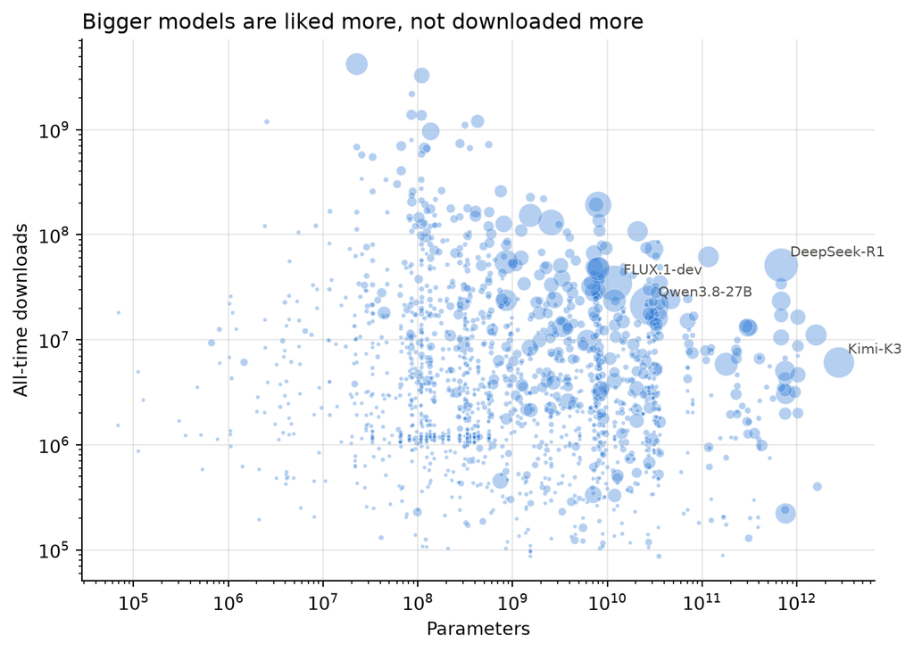

Parameters vs all-time downloads, both on a log scale. Point size is likes.

```python
has_size = models[models["num_parameters"] > 0]
fig, ax = plt.subplots(figsize=(8, 5.5))
ax.scatter(has_size["num_parameters"], has_size["downloads_all_time"], s=5 + has_size["likes"] / 40,
           color=BLUE, alpha=0.35, edgecolors="white", linewidths=0.5)
ax.set_xscale("log")
ax.set_yscale("log")
ax.set_xlabel("Parameters")
ax.set_ylabel("All-time downloads")
ax.set_title("Bigger models are liked more, not downloaded more")
for _, row in has_size.nlargest(4, "likes").iterrows():
    ax.annotate(row["model_id"].split("/")[-1], (row["num_parameters"], row["downloads_all_time"]), fontsize=8, color=GRAY, xytext=(5, 5), textcoords="offset points")
plt.show()
```

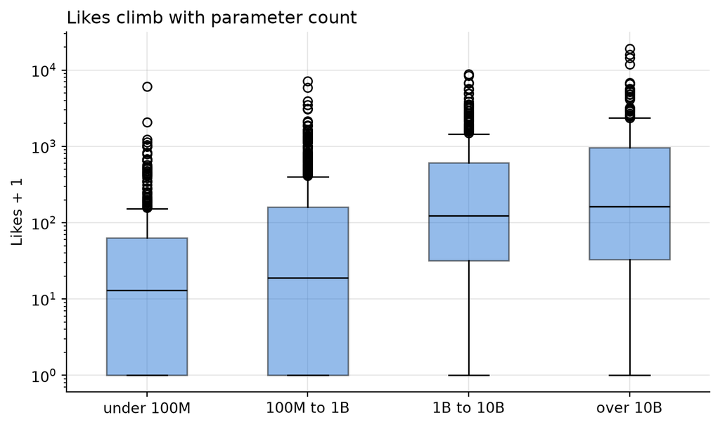

Likes by size class (log scale).

```python
order = ["under 100M", "100M to 1B", "1B to 10B", "over 10B"]
fig, ax = plt.subplots(figsize=(8, 4.5))
ax.boxplot([models.loc[models["size_class"] == s, "likes"] + 1 for s in order], tick_labels=order,
           widths=0.5, patch_artist=True, boxprops=dict(facecolor=BLUE, alpha=0.5), medianprops=dict(color="black"))
ax.set_yscale("log")
ax.set_ylabel("Likes + 1")
ax.set_title("Likes climb with parameter count")
plt.show()
```

```python
print("Correlation of log parameters with log downloads:", round(has_size["num_parameters"].apply("log10").corr(has_size["downloads_all_time"].apply("log10")), 3))
print("Correlation of log parameters with log likes:", round(has_size["num_parameters"].apply("log10").corr((has_size["likes"] + 1).apply("log10")), 3))
```

```
Correlation of log parameters with log downloads: -0.107
Correlation of log parameters with log likes: 0.426
```

Median downloads barely move across size classes (2.3M to 3.8M), and the smallest models actually get downloaded the most. Median likes go from 12 (under 100M) to 162 (over 10B), so people like the big models but run the small ones.

# Likes vs downloads

```python
print("Correlation of log likes and log downloads:", round((models["likes"] + 1).apply("log10").corr(models["downloads_all_time"].apply("log10")), 3))
print("\nMost liked:")
print(models.nlargest(5, "likes")[["model_id", "likes", "downloads_all_time"]].to_string(index=False))
print("\nMost liked per download (loved but not used):")
print(models.nlargest(5, "likes_per_million_downloads")[["model_id", "likes", "downloads_all_time"]].to_string(index=False))
print("\nFewest likes per download (used but not loved):")
print(models[models["likes"] > 0].nsmallest(5, "likes_per_million_downloads")[["model_id", "likes", "downloads_all_time"]].to_string(index=False))
```

```
Correlation of log likes and log downloads: 0.421

Most liked:
                    model_id  likes  downloads_all_time
            Qwen/Qwen3.8-27B  19153            21226079
black-forest-labs/FLUX.1-dev  15947            34541705
     deepseek-ai/DeepSeek-R1  14429            51154821
          moonshotai/Kimi-K3  11939             6074559
          Lightricks/LTX-2.5  10618             5759750

Most liked per download (loved but not used):
                            model_id  likes  downloads_all_time
deepseek-ai/DeepSeek-V4.1-Flash-1017   5268              221621
                 Qwen/Qwen-Image-2.1   3553              334679
              Cactus-Compute/whistle    551               75420
             google/embeddinggemma-2   3138              454477
                jialinyyzz/humanizer   2248              329203

Fewest likes per download (used but not loved):
                                                    model_id  likes  downloads_all_time
                                                 unslothai/1      1            84557149
  ybelkada/tiny-random-T5ForConditionalGeneration-calibrated      1            18063212
trl-internal-testing/tiny-Qwen2ForSequenceClassification-2.5      1            15463124
                   vllm-project/tiny-random-LlamaForCausalLM      2            25922747
                        dima806/fairface_age_image_detection     84           795806608
```

# Time

```python
print("Models with a real creation date:", models["created_at_known"].sum())
models["created_year"].value_counts().sort_index()
```

```
Models with a real creation date: 2671
```

```
created_year
2022.0    155
2023.0    263
2024.0    406
2025.0    869
2026.0    978
Name: count, dtype: int64
```

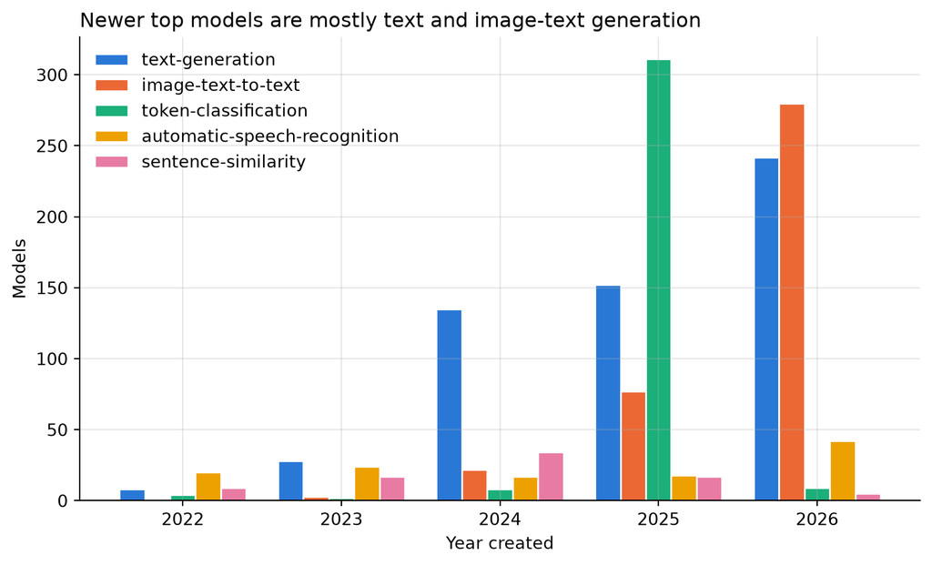

Models created per year among the top 3,000, for the five most common tasks. Models with the placeholder 2022-03-02 date are left out, and 2026 only runs through November 4.

```python
top_tasks = models["task"].value_counts().head(5).index
by_year = models[models["task"].isin(top_tasks)].groupby(["created_year", "task"]).size().unstack("task")[top_tasks]
colors = [BLUE, ORANGE, "#1baf7a", "#eda100", "#e87ba4"]
ax = by_year.plot.bar(figsize=(9, 5), color=colors, width=0.8, edgecolor="white")
ax.set_xlabel("Year created")
ax.set_ylabel("Models")
ax.set_title("Newer top models are mostly text and image-text generation")
ax.set_xticklabels([int(y) for y in by_year.index], rotation=0)
ax.legend(title="", frameon=False)
plt.show()
```

```python
print(models.groupby("created_year")[["downloads_all_time", "downloads_30d", "likes"]].median().round(0))
```

```
              downloads_all_time  downloads_30d  likes
created_year
2022.0                 7861732.0       235716.0   49.0
2023.0                 7213577.0       257566.0   53.0
2024.0                 4748818.0       231963.0   88.0
2025.0                 1292017.0       108359.0   16.0
2026.0                  941531.0       247813.0   88.0
```

Older models have more all-time downloads since they’ve had longer to collect them, but the 30-day downloads are about flat across years. The low 2025 medians are mostly the OpenMed upload.

# Papers

```python
print("Models with at least one arXiv paper:", (models["num_arxiv_papers"] > 0).sum())
print(models["paper_category"].value_counts().head(6))
print("\nDays from first paper to model creation:")
print(models["days_paper_to_model"].describe().round(0))
print("\nShare of models created before their paper:", round((models["days_paper_to_model"].dropna() < 0).mean(), 3))
```

```
Models with at least one arXiv paper: 1515
paper_category
cs.CL      903
cs.CV      329
cs.LG       89
cs.SD       48
eess.AS     39
cs.CY       31
Name: count, dtype: int64

Days from first paper to model creation:
count    1334.0
mean      411.0
std       715.0
min     -1315.0
25%       -18.0
50%        76.0
75%       605.0
max      4562.0
Name: days_paper_to_model, dtype: float64

Share of models created before their paper: 0.409
```

```python
models.groupby(models["num_arxiv_papers"] > 0)[["downloads_all_time", "likes"]].median().rename(index={True: "has paper", False: "no paper"}).round(0)
```

| num_arxiv_papers | downloads_all_time | likes |
| --- | --- | --- |
| no paper | 1684889.0 | 54.0 |
| has paper | 3014265.0 | 63.0 |

About half of the models link a paper, and those models get a few more likes (63 vs 54). cs.CL (language) papers outnumber cs.CV (vision) 903 to 329. The median gap from paper to model is 76 days, and about 40% of the models were on the Hub before the paper was posted.